# Mixed-Effects Models

Misc. Hierarchical Examples

**Review of Fixed vs. Random Effects** (Aho 2014)

Fixed factor levels have two characteristics: (1) they are not an obvious subset of a population of factor levels, and (2) the factor levels are informative, and are chosen by the investigator specifically because they have a unique and important meaning. Examples of fixed factor levels include:

- Male and female
- Predator and prey
- Drug A, drug B, and drug C
- Control and treatment
- Before and after
- Tree, grass, shrub, and so on
- Particular variants on a predictor, for example, “high”, “medium”, and “low”

Random factor levels have two characteristics: (1) the selected factor levels often can be considered a subset from a population of possible levels, and (2) the factor levels are not informative. Because of these characteristics, we are unlikely to care about particular differences among factor levels. Random factor levels include:

- Time intervals in a time sequence
- A collection of seed types (or some other levels) chosen randomly from a population of seed types (or some other population)
- Nested groups in an observational study
- Subjects on whom repeated measurements are made

If all factors contain fixed factor levels, then one would use a conventional fixed effect model for hypothesis testing procedures. Conversely, if all factors are random, then one should use a random effect model. A design with both random and fixed factors will require a *mixed effect model*. Fixed, random, and mixed effect models are also called model I, model II, and model III ANOVAs, respectively.  
**Examples of different types of hierarchical models** (Schielzeth and Nakagawa 2013, Methods in Ecology and Evolution) https://besjournals.onlinelibrary.wiley.com/doi/10.1111/j.2041-210x.2012.00251.x

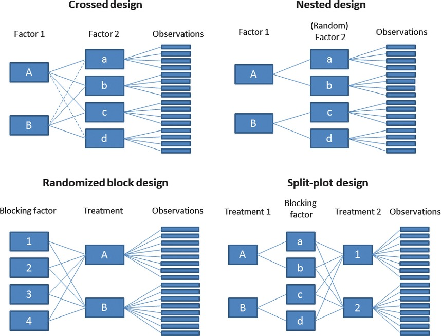

**Nested Design: Mosquito Wing Length** (Aho 2014, Example 10.13)  
Sokal and Rohlf (2012) measured the variability in wing length (in micrometers) for female mosquitos (*Aedes intrudens*). Four females were randomly selected from each of three cages and two measurements were made on the left wing of each. Both cage and female (in cage) can be seen as random effects. The data are in the dataframe mosquito.

```r
data(mosquito)
ggplot(mosquito, aes(cage, length, colour = female)) +
  geom_jitter(aes(fill=female), colour="black",pch=21, size=5, width = .05)
```

[output not shown]

```r
#Look at the coding of replicates in the mosquito dataset
mosquito
```

```r
mosquito.recoded <- read.csv("data/mosquito.recoded.csv")
ggplot(mosquito.recoded, aes(cage, length, colour = as.factor(female), shape=as.factor(measures))) +
  geom_jitter(width =0.15, size=5) +
  annotate("text", x = 2, y = 82.5, label = "12 females") +
  annotate("text", x = 2, y = 80, label = "2 measures per female") +
  annotate("text", x = 2, y = 77.5, label = "24 total measurements", size=5, color="blue")
```

[output not shown]

```r
aedes.1 <- lmer(length ~ (1|cage/female), data = mosquito)
anova(aedes.1)
```

```r
summary(aedes.1)
```

[output not shown]

Because the design is perfectly balanced, we can obtain the variance component estimates using mean squares from a conventional ANOVA. But this is confusing because df are different than what we might expect (there were only 12 mosquitos in the experiment).

```r
anova(lm(length ~ cage/female, data = mosquito))
```

[output not shown]

But maybe we are actually specifically interested in the differences among cages (cage as fixed effect); or if we had unbalanced sampling.

```r
aedes.2 <- lmer(length ~ cage + (1|cage/female), data = mosquito)
# aedes.wrong <- lmer(length ~ cage + (1|female), data = mosquito)
# this notation assumes every female is in every treatment; they are not
summary(aedes.2)
```

```r
anova(aedes.2)
```

We can test to see which model fits the data best.

```r
anova(aedes.2,aedes.1, test = "Chisq")
```

[output not shown]

Models are relatively indistinguishable. We can also use the `emmeans’ package to compare levels (see previous examples).  
**Nested Design: Liver Glycogen in Rats** (Aho 2014, Example 10.14)  
Sokal and Rohlf (2012) described a hierarchical experimental design to determine the effect of diet on glycogen levels in rat livers. **Six rats** were randomly assigned one of **three diets**: “control,” “compound 217,” and “compound 217 + sugar.” After a short period of time, the rats were euthanized and glycogen levels in their livers were measured. **Two glycogen measurements** were made for each of **three preparations of each liver** from each rat. In this case, the diet is fixed, while liver preparation (in diet) and glycogen measurements (in liver in diet) are random.

```r
#this visualization is a bit tough because of the way the data are coded (1, 2, 3)
data(rat) #from asbio package
ggplot(rat, aes(diet, glycogen, colour = liver)) +
  geom_point(size=5) +
  annotate("text", x = 3, y = 160, label = "6 rats, 3 diets = 2 rats/diet") +
  annotate("text", x = 2.85, y = 155, label = "3 liver sections, 2 measurements/section") +
  annotate("text", x = 2.85, y = 145, label = "OK, I'm confused now.")
```

As an exercise, make a schematic of what you expect this design to look like.

```r
rat_recoded <- read.csv("data/rat_recoded.csv")
ggplot(rat_recoded, aes(diet, glycogen, colour = as.factor(rat), shape=as.factor(liver))) +
  geom_jitter(width =0.15, size=5) +
  annotate("text", x = 3, y = 160, label = "3 diets with 2 rats/diet") +
  annotate("text", x = 2.85, y = 157, label = "3 liver sections") +
  annotate("text", x = 2.85, y = 154, label = "2 measurements/section") +
  annotate("text", x = 2.85, y = 145, label = "36 total measurements", size=5, color="blue")
```

[output not shown]

First, **lets do it the wrong way** and show how pseudoreplication can result in incorrect analyses. Of primary interest is the detection of differences in the fixed factor of diet. By treating each measure in each liver preparation in each rat as independent observations, we get a model with inflated degrees of freedom.

```r
anova(lm(glycogen ~ diet, data = rat))
```

[output not shown]

```r
rat.1 <- lmer(glycogen ~ diet + (1|diet/rat/liver), data = rat)
rat.1
```

```r
summary(rat.1)
```

```r
anova(rat.1)
```

[output not shown]

**Biodepth Example**

```r
biodepth <- read.delim("data/biodepth.txt", header=TRUE)
```

The BIODEPTH (Biodiversity and Ecosystem Processes in Terrestrial Herbaceous Ecosystems) project manipulated levels of grassland plant diversity in field plots to simulate the impact of the loss of plant species on ecosystem processes.

Source: Hector et al. 1999 Science ; Spehn et al. 2005 Ecological Monographs www.esapubs.org/archive/mono/M075/001

**Aim: Effects of diversity on yield within 8 European grasslands**

‘data.frame’: 480 obs. of 9 variables:

Plot : Factor w/ 480 levels (field plots = experimental units)

Site : Factor w/ 8 levels “Germany”,“Greece” (Fieldsites; **Random** grouping factor)

Block : Factor w/ 15 levels (2 blocks per site except Portugal; **Random** grouping factor)

Mix : Factor w/ 200 levels (partially crossed species mixtures within sites)

Mix_Nested: Factor w/ 220 levels (assuming full nesting of ecotypes within sites)

Diversity : No. of plant species per plot (primary explanatory variable (**Fixed** effect))

Shoot2 : Aboveground biomass harvested in year 2 (g m-2) [**Response**]

Shoot3 : Aboveground biomass harvested in year 3 (g m-2) [**Response**]

Diversity2: Diversity log transformed to base 2

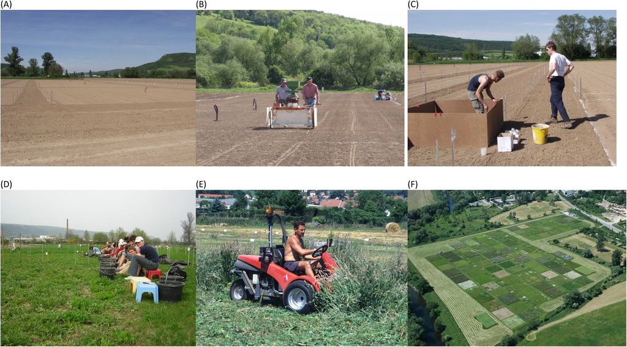

```r
biodepth$Mix <- factor(biodepth$Mix)
# Convert mixtures to factor
biodepth$Diversity2 <- log(biodepth$Diversity,2)
# transform log base 2
# Take year 2 as response variable
biodepth$Yield <- biodepth$Shoot2
str(biodepth)
```

```r
# Yield vs number of species for a 'no pooling analysis'
qplot(Diversity, Yield, data= biodepth, geom= c("point", "smooth"), method= "lm",
      xlab= "Number of species", ylab= "Yield", main= "No pooling analysis: Separated by Site (Country)",
      facets=.~Site)+scale_x_continuous(trans= "log2")+theme_bw()
```

[output not shown]

Note that the x-axis in the plots are log transformed because in general this produces approximately linear relationships (productivity cannot increase without limit, leading us to expect declining returns with increasing diversity which will be roughly linear once diversity is logged).

The point of fitting this model here is to help us understand the mixed-effects analysis we want to build from these initial simple extremes. One way to think of the mixed-effects analysis is as a **compromise between the no-pooling and complete-pooling models**.

Before we begin the mixed-effects analysis there is one more fixed-effects model we should fit.

```r
qplot(Diversity, Yield, data= biodepth,
      geom= c("point", "smooth"), method= "lm", main= "Complete pooling analysis: All sites combined",
      xlab= "Number of species", ylab= "Yield")+scale_x_continuous(trans= "log2")+theme_bw()
```

[output not shown]

**Mixed-model ANOVA using normal least squares**

Prior to the relatively recent introduction of modern mixed-effects models, a typical ecological analysis might well have consisted of fitting separate relationships for each site. However, we could also consider a normal least squares analysis using the `lm()` function that includes diversity, site, and the interaction. This is similar to an ANCOVA model:

```r
ls0 <- lm(Yield ~ Site + Diversity2 + Site:Diversity2, data=biodepth)
```

This model ignores the fact that the design is **blocked within sites**, and that the experiment also looks at the effects of species composition by replicating each species that is grown in monoculture and each mixture of species grown in polyculture (the factor Mix with 200 levels). To include these factors we have to extend from an ANCOVA to a more complex general linear model with several explanatory variables and nuisance terms.

```r
CH <- subset(biodepth, Site=="Switzerland")
# Reorder by levels of diversity
CH[order( factor(CH$Diversity) ), ]
# create colour and shape combinations to specify 32 mixtures
cols <- rep(c('black','red','green4','blue'), each = 8)
shapes <- rep(c(1:8),4)
FigTen3 <- qplot(Diversity, Yield, data= CH, geom= c("point"),
                 xlab= "Number of species", ylab= "Yield", main= "Example from Switzerland; note 32 combinations of mixtures",
                 facets=.~Block, colour=Mix, shape=Mix)+
                 scale_x_continuous(trans= "log2")+theme_bw()
FigTen3 + theme(legend.position="none") + scale_colour_manual(values=cols) + scale_shape_manual(values=shapes)
```

[output not shown]

```r
ls1 <- lm(terms(Yield~Site+Block+Diversity2+Site:Diversity2+Mix+Site:Mix, keep.order= TRUE), data= biodepth)
```

This type of complex **normal least squares analysis** with a combination of fixed and random effects is often called **mixed-model ANOVA**. The R code is unfortunately complex: we need the `terms()` function to specify the order in which the SS are calculated to be the same as the order of terms in the model sequence (otherwise R would put all the main effects first, then the two-way interactions, and so on, which does not work with this design since the diversity effects are a subset of the mixture effects—as you will see if you try fitting the mixture terms before the diversity terms).

```r
anova(ls1)
```

[output not shown]

One of the key messages is that it is normally better to focus on the estimates and intervals rather than the P-values (because what does it really mean when everything is ‘significant’?). Another take home message is that trying to do complex mixed-model analysis within the least squares framework is fraught with difficulties and limitations and it is **better to adopt the modern maximum likelihood-based approach** to mixed-effects models.

**Maximum likelihood-based mixed-effects models in R**

Start by fitting a model that doesn’t consider any interactions (keep it simple initially). We are analysing the response, yield, as a function of the fixed effect of diversity (using the log2 transformed version again) with simple random effects for sites, blocks, and mixtures. We will examine the way we specify the random effects in greater detail later but the key point to understand is that the `lme()` function **can only deal with nested random effects** as indicated by the forward slashes between site, block, and mix.

Example of Russian Dolls ‘Nested’ Within One Another; Analogous to Nested Effects in Model Specification

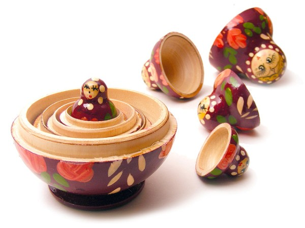

```r
library(nlme)
mem1 <- lme(Yield~Diversity2, random= ~1|Site/Block/Mix, na.action= na.exclude, data= biodepth)
summary(mem1)
```

[output not shown]

Understanding the difference between nested and crossed random effects is critical. First, `lme()` is really set up to deal only with fully nested designs, so if we want to use `lme()` we must be sure we have only nested random effects. Secondly, the newer `lme4` package can handle both nested and crossed random effects, which means that we must correctly specify them by coding them appropriately in the dataframe.

Whether random effects are nested or crossed is a property of the data, not the model. However, when fitting the model, effects can be included as either nested or crossed.

**Nested random effects** are when each member of one group is contained entirely within a single unit of another group. The canonical example is students in classrooms; you may have repeated measures per student, but each student belongs to a single classroom (assuming no reassignments).

**Crossed random effects** are when this nesting is not true. An example would be different seeds and different fields used for planting crops. Seeds of the same type can be planted in different fields, and each field can have multiple seeds in it.

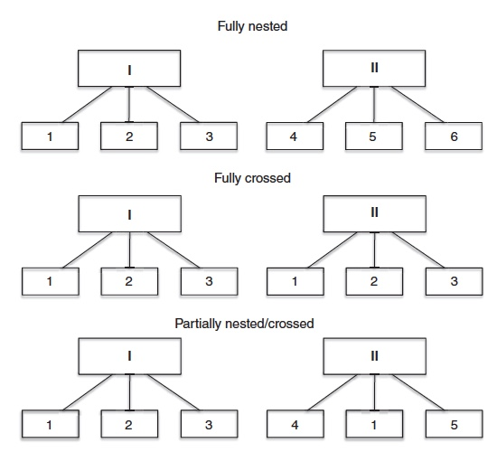

If each mixture occurred in only one block then the design would be fully nested. If every mixture was replicated in every block then the design would be fully crossed. In fact what we have is something in between that looks like the bottom panel. Mixtures in the BIODEPTH design are mostly nested within blocks but some do reoccur in different blocks introducing partial crossing.

In order to deal with designs with crossed random effects we have to use the `lmer()` function from the `lme4` package instead. The `lme4` package also contains the `lmList()` function that will fit an `lm()` model within each group—site in this case:

```r
detach(package: nlme) # to avoid potential conflicts with lme4
library(lme4)
lmList(Yield~Diversity2|Site, data= biodepth)
```

[output not shown]

The model-building approach recommends starting with a model that is as complex or slightly more complex than we anticipate we will need. We can then consider whether or not to simplify this model. In this case we could begin with a model including interactions for both the site-by-diversity and site-by-mixture terms (the crossed random effects).

The site-by-diversity interaction in the random effects allows variation among sites in the regression intercepts and slopes and is sometimes called a **random intercepts and slopes model** (as opposed to one with random intercepts only where the slopes are fixed to be parallel at different sites). Helpfully, the syntax for fitting mixed-effects models in `lmer()` has been simplified relative to `lme()`:

```r
mer1 <- lmer(Yield~Diversity2 +(1+Diversity2|Site)+(1|Block)+(1|Mix)+(1|Site:Mix), data= biodepth)
summary(mer1)
```

[output not shown]

##Likelihood ratio tests of random effects

In model-building, we would normally want to keep the main effects for sites, blocks, and mixtures since they reflect the core structure of the design, but we could consider whether or not to include the interaction terms. The recommended approach is to remove one term at a time from the random effects and to judge whether to retain it or not using a likelihood ratio test to compare the model with and without the effect in question (considering only one effect at a time).

Note that these are ‘nested models’!

```r
mer1 <- lmer(Yield~Diversity2 +(1+Diversity2|Site)+(1|Block)+(1|Mix)+(1|Site:Mix), data= biodepth) #from above
mer2 <- lmer(Yield~Diversity2 +(1+Diversity2|Site)+(1|Block)+(1|Mix), data= biodepth)
anova(mer1, mer2)
```

[output not shown]

Following this approach we will keep the site-by-mixture interaction in the random effects. Although we would normally retain the random effect for block in the model to reflect its role in the design we can test its importance here as a demonstration of how optional terms could be removed from the random effects:

```r
mer3 <- lmer(Yield~Diversity2 +(1+Diversity2|Site)+(1|Mix)+(1|Site:Mix), data= biodepth)
anova(mer1, mer3)
```

[output not shown]